Machine Learning

[figure not shown]

# AI & Machine Learning - Unit 2

### 3. Eigendecomposition, Principal Component Analysis (PCA), 3DMM

**Prof. Iacopo Masi - Computer Science Department, Sapienza University of Rome**

# Recap the previous lecture

- Vector and Matrix as a formal way to represent data
- Why LA? (data, covariance matrix, calculus)
- Operations (vector to vector, matrix to vector, inner product)
- Geometric Interpretation of the inner product
- Subspaces/Rank/Inverse
- Projection onto a subspace

# This lecture material is taken from

- ### Note: you can find PCA on Chapter 12 of [Bishop Book]
- [Geometry of the Transformations](https://en.wikipedia.org/wiki/Geometric_transformation)
- [Geometry of Transformations take 2](https://math.hmc.edu/calculus/hmc-mathematics-calculus-online-tutorials/linear-algebra/geometry-of-linear-transformations/)
- [This pdf covers this part](http://cs229.stanford.edu/summer2019/cs229-linalg.pdf)
- [Illustrations and some math parts are taken from d2l.ai, eigendecomposition](https://d2l.ai/chapter_appendix-mathematics-for-deep-learning/eigendecomposition.html)
- [Code for Eigendecomposition](https://hadrienj.github.io/posts/Deep-Learning-Book-Series-2.7-Eigendecomposition/)

## Determinant

The geometric view of linear algebra gives an intuitive way to interpret a fundamental quantity known as the *determinant*. Consider the grid image from before, but now with a highlighted region below.

[figure not shown]

Look at the highlighted square. This is a square with edges given by $(0, 1)$ and $(1, 0)$ and thus it has area one. After $\mathbf{A}$ transforms this square, we see that it becomes a parallelogram. There is no reason this parallelogram should have the same area that we started with, and indeed in the specific case shown here of

$$ \mathbf{A} = \begin{bmatrix} 1 & 2 \\ -1 & 3 \end{bmatrix}, $$

it is an exercise in coordinate geometry to compute the area of this parallelogram and obtain that the area is $5$.

In general, if we have a matrix

$$ \mathbf{A} = \begin{bmatrix} a & b \\ c & d \end{bmatrix}, $$

we can see with some computation that the area of the resulting parallelogram is $ad-bc$. This area is referred to as the *determinant*.

## Determinant $\rightarrow$ Hyper-volume ratio

[figure not shown]

**Sanity Check:** We cannot apply Pythagoras' Theorem to compute area because axes are not aligned anymore.

The picture is misleading since the axes are **CLOSED to be aligned**.

[output not shown]

```python
is_basis = False # toggle this to compare the angles
X = np.array([[1, 0], [0, 1]]) if is_basis else np.array([[1, -1], [2, 3]])
theta_rad = angle(*X)
theta = theta_rad*180/np.pi
print(theta)
```

```
101.30993247402021
```

# Transformations of Linear Maps

## No transformation! Identity matrix

## Translation or Displacement (for now let's leave it a side)

**Preserve distances and oriented angles**

[figure not shown]

## Isometries (Euclidean): Rotation and Translations

**Preserve angles and distances**

$$A = \left[\begin{array}{cc}\cos\theta ~~~ -\sin\theta \\\sin\theta ~~~ \cos\theta\end{array} \right]$$

This is easily derived by noting that

[figure not shown]

```
[[ 0.70710678 -0.70710678]
 [ 0.70710678  0.70710678]]
```

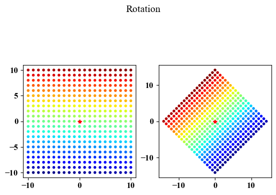

```python
ang = np.pi/4
A = np.array([[np.cos(ang), -np.sin(ang)],
              [np.sin(ang),np.cos(ang)]])
print(A)
Xd, Yd = linear_map(A, Xs, Ys)
fig, axs = plt.subplots(1,2)
fig.suptitle('Rotation')
plot_grid(Xs,Ys,axs[0])
plot_grid(Xd,Yd,axs[1])
```

## Similarity (Euclidean): scale, reflection (flip), Rotation and Translations

**Preserve angles and RATIO between distances**

$$A = \left[\begin{array}{cc}s_x\cos\theta ~~~ -\sin\theta \\\sin\theta ~~~ s_y\cos\theta\end{array} \right]$$

This is easily derived by noting that

[figure not shown]

```
[[ 1.41421356 -0.70710678]
 [ 0.70710678  1.41421356]]
```

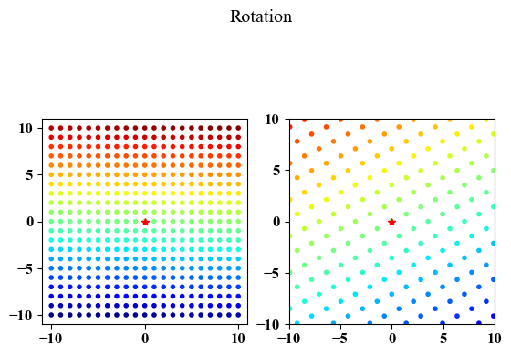

```python
ang, scale, clip = np.pi/4, 2, True
A = np.array([[scale*np.cos(ang), -np.sin(ang)],
              [np.sin(ang), scale*np.cos(ang)]])
print(A)
Xd, Yd = linear_map(A, Xs, Ys)
fig, axs = plt.subplots(1, 2)
fig.suptitle('Rotation')
plot_grid(Xs, Ys, axs[0])
plot_grid(Xd, Yd, axs[1])
if clip:
    plt.xlim(-nX, nX)
    plt.ylim(-nY, nY)
```

## Affine: shear, scale, reflection (flip), Rotation and Translations

**Preserve parallelism (but NOT angles!)**

$$A = \left[\begin{array}{cc}s_x\cos\theta ~~~ -c_x\sin\theta \\c_y\sin\theta ~~~ s_y\cos\theta\end{array} \right]$$

This is easily derived by noting that

[figure not shown]

```
[[ 1.41421356 -5.65685425]
 [ 1.41421356  1.41421356]]
```

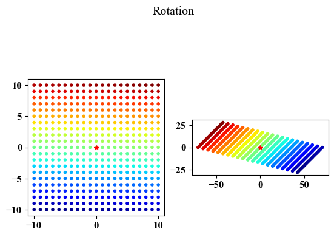

```python
ang, scale, cx_shear, cy_shear,clip = np.pi/4, 2, 8, 2, False
A = np.array([[scale*np.cos(ang), -cx_shear*np.sin(ang)],
              [cy_shear*np.sin(ang), scale*np.cos(ang)]])
print(A)
Xd, Yd = linear_map(A, Xs, Ys)
fig, axs = plt.subplots(1, 2)
fig.suptitle('Rotation')
plot_grid(Xs, Ys, axs[0])
plot_grid(Xd, Yd, axs[1])
if clip:
    plt.xlim(-nX, nX)
    plt.ylim(-nY, nY)
```

# Hyperplanes

**Hyperplane**: a generalization to higher dimensions of a line ($D=2$) or of a plane ($D=3$). In a $d$-dimensional vector space, a hyperplane has $d-1$ dimensions and **divides the space into two half-spaces.**

$$ \mathbf{w}\mathbf{x} + \mathbf{b} = 0 $$

where $\mathbf{w}$ is a vector normal to the hyperplane and $\mathbf{b}$ is an offset

[figure not shown]

# Hyperplanes

**Hyperplane**: a generalization to higher dimensions of a line ($D=2$) or of a plane ($D=3$). In an $d$-dimensional vector space, a hyperplane has $d-1$ dimensions and **divides the space into two half-spaces.**

$$ \mathbf{w}\mathbf{x} + \mathbf{b} = 0$$

where $\mathbf{w}$ is a vector normal to the hyperplane and $\mathbf{b}$ is an offset

[figure not shown]

# Projection

Suppose that we have two vectors $\mathbf{v}$ and a column vector $\mathbf{w}=[2,1]^\top$.

**We want to project $\mathbf{v}$ onto $\mathbf{w}$ or better project v onto the subspace (line in this case) of $\mathbf{w}$.**

Recalling trigonometry, we see the formula $\|\mathbf{v}\|\cos(\theta)$ is the length of the projection of the vector $\mathbf{v}$ onto the direction of $\mathbf{w}$

[figure not shown]

## Projection vector onto subspace defined by $\mathbf{w}$

$$\mathbb{P}_\mathbf{w}(\mathbf{v}) = \frac{\mathbf{w}\mathbf{w}^T}{\mathbf{w}^T\mathbf{w}}\mathbf{v} = \left( \frac{\mathbf{w}}{||\mathbf{w}||}\right)\left(\frac{\mathbf{w}}{||\mathbf{w}||}\right)^T\mathbf{v}$$

Defining a unit vector $\mathbf{\hat{w}}=\frac{\mathbf{w}}{||\mathbf{w}||}$ we have: $$\mathbb{P}_\mathbf{w}(\mathbf{v}) = \underbrace{\mathbf{\hat{w}}}_{\text{direction}} \left(\underbrace{\mathbf{\hat{w}}^T \mathbf{v}}_{\text{length}}\right)$$

- Projection must be on unit vector $\alpha\cdot\mathbf{\hat{w}}$
- How long in this direction? $\alpha=\mathbf{\hat{w}}^T \mathbf{v}$ that gives the length of **v** onto **w**.
- **$\mathbf{w}$** can be also a matrix, not a vector (a matrix in which columns are vectors).

# This lecture material is taken from

- [Geometry of the Transformations](https://en.wikipedia.org/wiki/Geometric_transformation)
- [Geometry of Transformations take 2](https://math.hmc.edu/calculus/hmc-mathematics-calculus-online-tutorials/linear-algebra/geometry-of-linear-transformations/)
- [This pdf covers this part](http://cs229.stanford.edu/summer2019/cs229-linalg.pdf)
- [Illustrations and some math parts are taken from d2l.ai, eigendecomposition](https://d2l.ai/chapter_appendix-mathematics-for-deep-learning/eigendecomposition.html)
- [Code for Eigendecomposition](https://hadrienj.github.io/posts/Deep-Learning-Book-Series-2.7-Eigendecomposition/)

# Today's lecture

## Decomposition (Eigen, SVD), PCA (we use projection!)

## Applications of PCA

## Recap on Calculus

## ⚠️ All the examples are in 2D but generalizes to 3D and N-D

- Machine Learning is about thinking in N-dimensional space
- ...especially for vision problems (images, videos)
- 2D is used for the sake of visualization and clarity in the explanation

# Eigendecomposition

Suppose that we have a matrix $A$ with the following entries:

$$ \mathbf{A} = \begin{bmatrix} 2 & 0 \\ 0 & -1 \end{bmatrix}. $$

If we apply $A$ to any vector $\mathbf{v} = [x, y]^\top$, we obtain a vector $\mathbf{A}\mathbf{v} = [2x, -y]^\top$. This has an intuitive interpretation: stretch the vector to be twice as wide in the $x$-direction, and then flip it in the $y$-direction.

**However, there are *some* vectors for which something remains unchanged.**

Namely $[1, 0]^\top$ gets sent to $[2, 0]^\top$ and $[0, 1]^\top$ gets sent to $[0, -1]^\top$.

These vectors are still in the same line, and the only modification is that the matrix stretches them by a factor of $2$ and $-1$ respectively. **We call such vectors *eigenvectors* and the factor they are stretched by *eigenvalues*.**

In general, if we can find a number $\lambda$ and a vector $\mathbf{v}$ such that

$$ \underbrace{\mathbf{A}}_{\text{known}}\mathbf{v} = \underbrace{\lambda\mathbf{v}}_{\text{unknown}} $$

We say that $\mathbf{v}$ is an eigenvector for $A$ and $\lambda$ is an eigenvalue.

## Finding Eigenvalues

$$(\mathbf{A} - \lambda \mathbf{I})\mathbf{v} = 0.$$

For the equation to happen, we see that $(\mathbf{A} - \lambda \mathbf{I})$ must compress some direction down to zero, hence it is not invertible, and thus the determinant is zero. Thus, we can find the *eigenvalues* by finding for what $\lambda$ is $\det(\mathbf{A}-\lambda \mathbf{I}) = 0$. Once we find the eigenvalues, we can solve $\mathbf{A}\mathbf{v} = \lambda \mathbf{v}$ to find the associated *eigenvector(s)*.

### An Example

Let's see this with a more challenging matrix

$$ \mathbf{A} = \begin{bmatrix} 2 & 1\\ 2 & 3 \end{bmatrix}. $$

If we consider $\det(\mathbf{A}-\lambda \mathbf{I}) = 0$, we see this is equivalent to the polynomial equation $0 = (2-\lambda)(3-\lambda)-2 = (4-\lambda)(1-\lambda)$. Thus, two eigenvalues are $4$ and $1$. To find the associated vectors, we then need to solve

$$ \begin{bmatrix} 2 & 1\\ 2 & 3 \end{bmatrix}\begin{bmatrix}x \\ y\end{bmatrix} = \begin{bmatrix}1x \\ 1y\end{bmatrix} \; \text{and} \; \begin{bmatrix} 2 & 1\\ 2 & 3 \end{bmatrix}\begin{bmatrix}x \\ y\end{bmatrix} = \begin{bmatrix}4x \\ 4y\end{bmatrix} . $$

We can solve this with the vectors $[1, -1]^\top$ and $[1, 2]^\top$ respectively.

```python
eigs, eigvects = np.linalg.eig(
                 np.array([[2, 1],
                           [2, 3]]))
print(f'Eigen val:\n {eigs}', end='\n\n')
print(f'EigenVect vect:\n {eigvects}')
# Note that `numpy` normalizes the eigenvectors to be of length one,
# whereas we took ours to be of arbitrary length.
# Additionally, the choice of the sign is arbitrary.
# However, the vectors computed are parallel
# to the ones we found by hand with the same eigenvalues.
#help(np.linalg.eig)
```

```
Eigen val:
 [1. 4.]

EigenVect vect:
 [[-0.70710678 -0.4472136 ]
 [ 0.70710678 -0.89442719]]
```

# Geometric Interpretation of Eigenvectors

# Parametric Unit Sphere

\begin{equation} \Big\{ t \in [0,2\pi]~~|~~ x=\cos(t),y=\sin(t) \Big\} \end{equation}

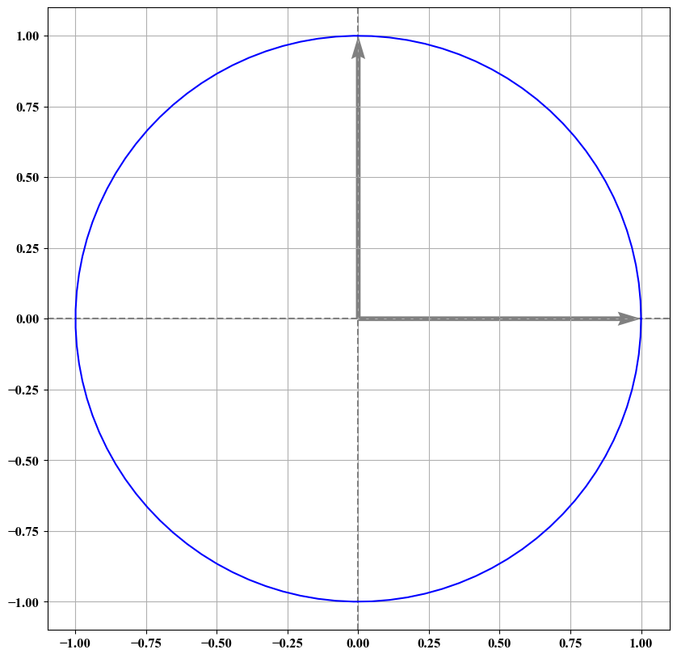

```python
fig_dim = 10
### Unit Sphere
# Parametric sphere
t = np.linspace(0, 2*np.pi, 100) # seems a circle but it is not (move the resolution to 10)
Xs = np.cos(t)
Ys = np.sin(t)

# Plot
fig, ax = plt.subplots()
fig.set_figheight(fig_dim)
fig.set_figwidth(fig_dim)
plot_points(ax, Xs, Ys, col='blue')
plt.show()
```

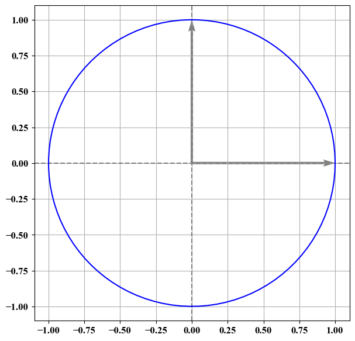

```python
fig_dim = 7
### Unit Sphere
# Parametric sphere
t = np.linspace(0, 2*np.pi, 100) # seems a circle but it is not (move the resolution to 10)
Xs = np.cos(t)
Ys = np.sin(t)

# Plot
fig, ax = plt.subplots()
fig.set_figheight(fig_dim)
fig.set_figwidth(fig_dim)
plot_points(ax, Xs, Ys, col='blue')
plt.show()
```

# Linear Transform to Unit Sphere

- For each point $\mathbf{p}=(x,y)$ apply the transform $\mathbf{A}\mathbf{p}^T$
- Plot the result
- We can do it without using for loop (we used it in the previous lecture)
  - by stacking all **p** column-wise into a matrix **P**
  - then doing `A@P`
- For now, assume:
  - `A` is square

```python
# Define a transform
limit = 2.5
# Define a transformation
# A = np.array([[1.5, 1],
#               [1, 1.5]])
A = np.array([[1, -1],
              [-1, 2]])
print(f'Transformation is\n {A}')
```

```
Transformation is
 [[ 1 -1]
 [-1  2]]
```

```python
# Map points on the surface
Xd, Yd = linear_map(A, Xs, Ys)
# let's map the basis
Xu_d, Yu_d = linear_map(A, np.array([1,0]), np.array([0,1]))
units_d = np.stack((Xu_d, Yu_d),axis=1)
# Compute the eigenvalues and eigenvectors
eigVals, eigVecs = np.linalg.eig(A)
print('eigVals', eigVals, 'eigVecs', eigVecs, sep='\n'*2)
```

```
eigVals

[0.38196601 2.61803399]

eigVecs

[[-0.85065081  0.52573111]
 [-0.52573111 -0.85065081]]
```

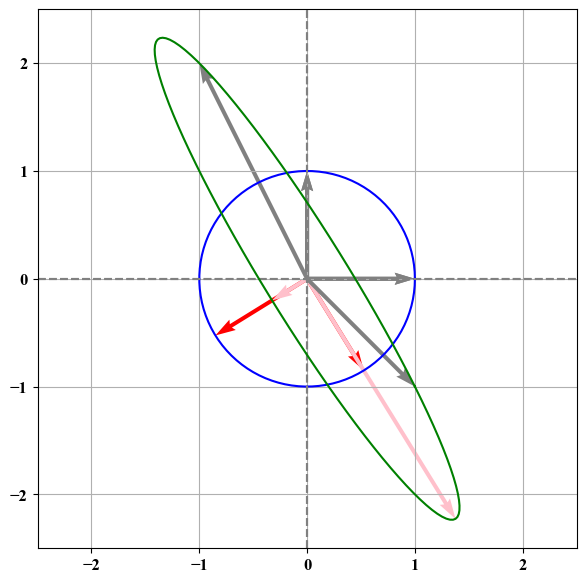

```python
# Plot src points and destination points
fig, ax = plt.subplots(1,1)
fig.set_figheight(fig_dim)
fig.set_figwidth(fig_dim)
# Plot src
plot_points(ax, Xs, Ys, col='blue')
# Plot destination
plot_points(ax, Xd, Yd, col='green')
ax.set_aspect('equal')
ax.set_xlim(-limit,limit)
ax.set_ylim(-limit,limit)
# Plot normalized eigenvectors (unit 1)
plotVectors(ax, [eigVecs[:,0], eigVecs[:,1]],
            cols=['red']*2)
# Plot unnormalized eigenvectors (unit 1)
# we have to multiply back to its own eig val
plotVectors(ax, [eigVals[0]*eigVecs[:,0], eigVals[1]*eigVecs[:,1]],
            cols=['pink']*2)
plotVectors(ax, [Xu_d, Yu_d ],
            cols=['gray']*2)
```

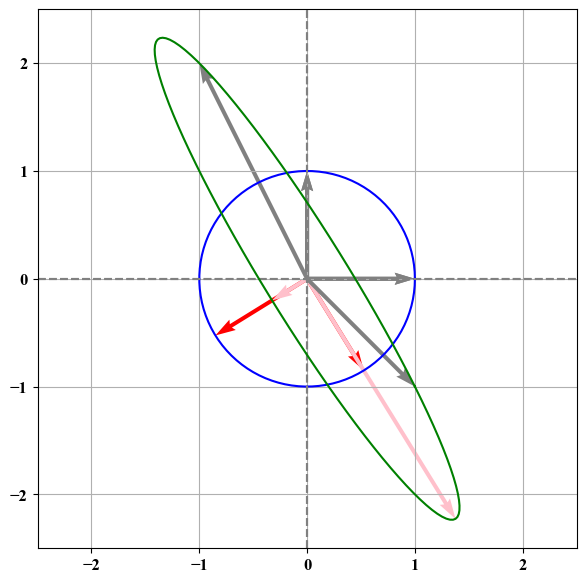

```python
# Plot src points and destination points
fig, ax = plt.subplots(1,1)
fig.set_figheight(fig_dim)
fig.set_figwidth(fig_dim)
# Plot src
plot_points(ax, Xs, Ys, col='blue')
# Plot destination
plot_points(ax, Xd, Yd, col='green')
ax.set_aspect('equal')
ax.set_xlim(-limit,limit)
ax.set_ylim(-limit,limit)
# Plot normalized eigenvectors (unit 1)
plotVectors(ax, [eigVecs[:,0], eigVecs[:,1]],
            cols=['red']*2)
# Plot unnormalized eigenvectors (unit 1)
# we have to multiply back to its own eig val
plotVectors(ax, [eigVals[0]*eigVecs[:,0], eigVals[1]*eigVecs[:,1]],
            cols=['pink']*2)
plotVectors(ax, [Xu_d, Yu_d ],
            cols=['gray']*2)
```

## Eigendecomposition of Matrices

$$ \mathbf{W} = \begin{bmatrix} 1 & 1 \\ -1 & 2 \end{bmatrix}, $$

be the matrix where the columns are the eigenvectors of the matrix $\mathbf{A}$. Let

$$ \boldsymbol{\Sigma} = \begin{bmatrix} 1 & 0 \\ 0 & 4 \end{bmatrix}, $$

be the matrix with the associated eigenvalues on the diagonal. Then the definition of eigenvalues and eigenvectors tells us that

$$ \mathbf{A}\mathbf{W} =\mathbf{W} \boldsymbol{\Sigma} . $$

The matrix $W$ is invertible, so we may multiply both sides by $W^{-1}$ on the right, we see that we may write

$$\mathbf{A} = \mathbf{W} \boldsymbol{\Sigma} \mathbf{W}^{-1}.$$

if $\mathbf{W}$ is invertible

## Operations on Eigendecompositions

One nice thing about eigendecompositions is that we can write many operations we usually encounter cleanly in terms of the eigendecomposition. As a first example, consider:

$$ \mathbf{A}^n = \overbrace{\mathbf{A}\cdots \mathbf{A}}^{\text{$n$ times}} = \overbrace{(\mathbf{W}\boldsymbol{\Sigma} \mathbf{W}^{-1})\cdots(\mathbf{W}\boldsymbol{\Sigma} \mathbf{W}^{-1})}^{\text{$n$ times}} = \mathbf{W}\overbrace{\boldsymbol{\Sigma}\cdots\boldsymbol{\Sigma}}^{\text{$n$ times}}\mathbf{W}^{-1} = \mathbf{W}\boldsymbol{\Sigma}^n \mathbf{W}^{-1}. $$

This tells us that for any positive power of a matrix, the eigendecomposition is obtained by just raising the eigenvalues to the same power. The same can be shown for negative powers, so if we want to invert a matrix we need only consider

$$ \mathbf{A}^{-1} = \mathbf{W}\boldsymbol{\Sigma}^{-1} \mathbf{W}^{-1}, $$

or in other words, just invert each eigenvalue.

# Spectral Theorem

Informal: Given a matrix $\mathbf{A}$ **squared and symmetric**, $\mathbf{A} \in \mathbb{R}^{d\times d}$ and $\mathbf{A} = \mathbf{A}^T$ then:

- All the eigenvalues take **real values**
- The eigenvectors are all **orthogonal**

### Practical applications:

- Hessian, Covariance Matrices
- Kernel matrices, Projection Matrices

## Eigendecompositions of Symmetric Matrices

- Hessian
- Covariance Matrices
- PCA
- Kernels etc

[output not shown]

# Decomposition as a Geometric Pipeline

$$\mathbf{A}\mathbf{x} = \underbrace{(\mathbf{U} \underbrace{(\mathbf{\Sigma}\underbrace{(\mathbf{U}^{-1}\mathbf{x})}_{\text{1st step/rotate}})}_{\text{2nd step/scale}})}_{\text{3rd step/rotate}}$$

[output not shown]

# Decomposition as a Geometric Pipeline (Code)

```python
print('A', A, sep='\n\n')
Sigma, U = np.diag(eigVals), eigVecs
print('Sigma', Sigma, 'U', U, sep='\n\n')
```

```
A

[[ 1 -1]
 [-1  2]]
Sigma

[[0.38196601 0.        ]
 [0.         2.61803399]]

U

[[-0.85065081  0.52573111]
 [-0.52573111 -0.85065081]]
```

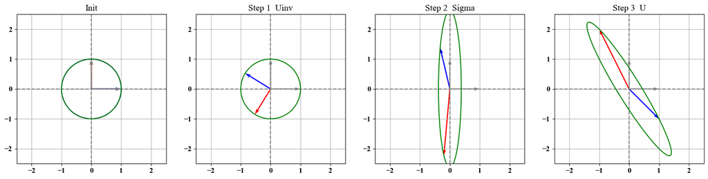

```python
# Plot src points and destination points
fig, axes = plt.subplots(1, 4)
fig.set_figheight(20)
fig.set_figwidth(20)
# apply [Id, Uinv, Sigma, U]
Trans = [np.diag((1, 1)), U.T, Sigma, U]
titles = ['Init', 'Step 1  Uinv', 'Step 2  Sigma', 'Step 3  U']
X_orig = np.array([1, 0])
Y_orig = np.array([0, 1])
Xss = np.copy(Xs)
Yss = np.copy(Ys)
for count, (ax, T, title) in enumerate(zip(axes, Trans, titles)):
    ax.set_xlim(-limit, limit)
    ax.set_ylim(-limit, limit)
    ax.set_aspect('equal')
    ax.set_title(title)
    Xss, Yss = linear_map(T, Xss, Yss)
    X_orig, Y_orig = linear_map(T, X_orig, Y_orig)
    if count == 0:
        plot_points(ax, Xs, Ys, col='blue')
    unit_v = np.stack((X_orig, Y_orig), axis=1)
    plotVectors(ax, unit_v, ['blue', 'red'])
    plot_points(ax, Xss, Yss, col='green')
```

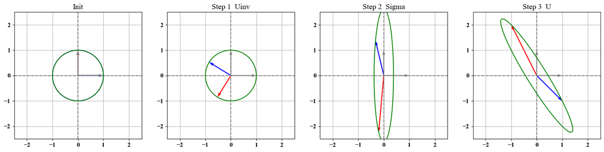

```python
# Plot src points and destination points
fig, axes = plt.subplots(1, 4)
fig.set_figheight(20)
fig.set_figwidth(20)
# apply [Id, Uinv, Sigma, U]
Trans = [np.diag((1, 1)), U.T, Sigma, U]
titles = ['Init', 'Step 1  Uinv', 'Step 2  Sigma', 'Step 3  U']
X_orig = np.array([1, 0])
Y_orig = np.array([0, 1])
Xss = np.copy(Xs)
Yss = np.copy(Ys)
for count, (ax, T, title) in enumerate(zip(axes, Trans, titles)):
    ax.set_xlim(-limit, limit)
    ax.set_ylim(-limit, limit)
    ax.set_aspect('equal')
    ax.set_title(title)
    Xss, Yss = linear_map(T, Xss, Yss)
    X_orig, Y_orig = linear_map(T, X_orig, Y_orig)
    if count == 0:
        plot_points(ax, Xs, Ys, col='blue')
    unit_v = np.stack((X_orig, Y_orig), axis=1)
    plotVectors(ax, unit_v, ['blue', 'red'])
    plot_points(ax, Xss, Yss, col='green')
```

# Geometry of SVD

Source: Wikipedia

[figure not shown]

# Principal Component Analysis (PCA)

### PCA works in unsupervised learning settings

\begin{equation} \underbrace{\{\mathbf{x}_i\}_{i=1}^N}_{\text{known}} \sim \underbrace{\mathcal{D}}_{\text{unknown}} \end{equation}

### Assumptions

- $\mathbf{x}_i \in \mathbb{R}^D$
- $N \geq D$ (number of points higher than number of features; or else, more points than dimensions..for now...)
- $D \geq k$ (where k is the dimension of the subspace on which we will project the points | number of components we will take)

### Objective: find a transformation for compressing the data.

### What does it mean compressing data? Maybe have different meanings

### Which kind of transformation?

```python
########### We know the generative model of the data D ############
np.random.seed(0) # fixing the seed
n_samples=100; cov = [[3, 3], [3, 4]]
# Assumes know the generative model of data
X = np.random.multivariate_normal(mean=[1, 1], cov=cov, size=n_samples)
###########################################################
```

```
num of points 100 in dimension 2
```

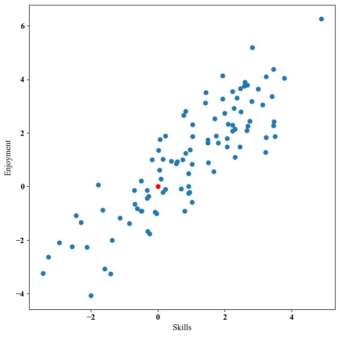

```python
print(f'num of points {X.shape[0]} in dimension {X.shape[1]}')
fig = plt.figure(figsize=(8,8))
plt.scatter(*X.T)
plt.scatter(0, 0, c='r', marker='o')
plt.ylabel('Enjoyment')
_ = plt.xlabel('Skills')
```

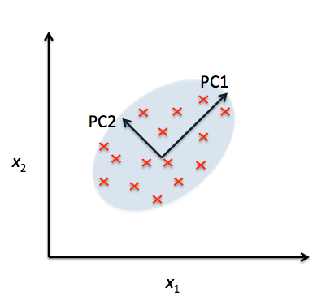

# Covariance Matrix: the shape of the input matrix matters

- $\mathbf{X} \in \mathbb{R}^{N\times D}$
- N=samples [rows] in D dimensional space [cols]

then the covariance matrix needs to be $ \in \mathbb{R}^{D\times D}$: $$\mbf{C} = \frac{1}{N} (\mathbf{X}-\boldsymbol{\mu})^T(\mathbf{X}-\boldsymbol{\mu}) $$

# Covariance Matrix: the shape of the input matrix matters

- $\mathbf{X} \in \mathbb{R}^{D\times N}$
- N=samples [columns] in D dimensional space [row]

then the covariance matrix needs to be $ \in \mathbb{R}^{D\times D}$: $$\mbf{C} = \frac{1}{N} (\mathbf{X}-\boldsymbol{\mu})(\mathbf{X}-\boldsymbol{\mu})^T $$

## First Step: Standardize the data

- Assumptions that $\mathbf{X}$ is sampled from multi-variate Gaussian distribution
- **Center all the data in the center (origin)**. **Compute the mean and remove it.**
- **[Optional] Rescale all axes so that the standard deviation is one.**

$$ \mathbf{X}^{\prime} \leftarrow \frac{\mathbf{X} - \mathbf{\mu}}{\mathbf{\sigma}} $$

After: $ \mathbf{X}^{\prime}$ is **standardized**

### Objective: find a transformation (subspace) for compressing the data

- Which subspace are we going to find? 🤔
- There could be more than one!

## Second Step: Finding the components

- PCA finds a subspace that **maximizes the variance of the data.**
- Given the input $D$-dimensional space, PCA finds a $k$-dimensional subspace that maximizes the variance of data.
- Motivation: **compress the dimensions, but keep most of the information i.e. preserve the variance of the data as much as possible**

# Play a game

### I will show you a point cloud,

### you tell me STOP when the variance of the data is maximized on the subspace

[figure not shown]

[Taken from StackExchange](https://stats.stackexchange.com/questions/2691/making-sense-of-principal-component-analysis-eigenvectors-eigenvalues)

- Find $\mathbf{u}\in \mathbb{R}^D $ s.t. $\left\|\mathbf{u}\right\|_2=1$ for which you can project the data $\mathbf{x}^{\prime}=\mathbb{P}_{\mathbf{u}}\mathbf{x}$

$$ \mathbb{P}_{\mathbf{u}}\mathbf{x} = \frac{\mathbf{u}\mathbf{u}^T}{\mathbf{u}^T\mathbf{u}}\mathbf{x} = (\mathbf{x}^T\mathbf{u})\mathbf{u}$$

- We have to maximize the variance once projected.
- Which means making the projection of **x** with **u** **large**:
- We can measure the **size** of the projection with $\ell_2^2$ norm.

$$\arg\max_{\mathbf{u}} \frac{1}{N}\sum_i^N \left\| \mathbb{P}_{\mathbf{u}}\mathbf{x}_i \right\|_2^2$$

- Find $\mathbf{u}\in \mathbb{R}^k$ s.t. $\left\|\mathbf{u}\right\|_2=1$ for which you can project the data $\mathbf{x}^{\prime}=\mathbb{P}_{\mathbf{u}}\mathbf{x}$

$$ \mathbb{P}_{\mathbf{u}}\mathbf{x} = \frac{\mathbf{u}\mathbf{u}^T}{\mathbf{u}^T\mathbf{u}}\mathbf{x} = (\mathbf{x}^T\mathbf{u})\mathbf{u}$$

- We have to maximize the variance once projected.
- Which means making the projection of **x** with **u** **large**:
- We can measure the **size** of the projection with $\ell_2$ norm.

$$\arg\max_{\mathbf{u}} \frac{1}{N}\sum_i^N \left\| \mathbb{P}_{\mathbf{u}}\mathbf{x} \right\|_2^2 \rightarrow \arg\max_{\mathbf{u}} \frac{1}{N}\sum_i^N \left\| (\mathbf{x}_i^T\mathbf{u})\mathbf{u}\right\|_2^2$$

$$\arg\max_{\mathbf{u}} \frac{1}{N}\sum_i^N \left\| (\mathbf{x}_i^T\mathbf{u})\mathbf{u}\right\|_2^2=\frac{1}{N}\sum_i^N (\mathbf{x}_i^T\mathbf{u})^2 = \frac{1}{N}\sum_i^N ( \mathbf{x}_i^T\mathbf{u})(\mathbf{x}_i^T\mathbf{u}) = \frac{1}{N}\sum_i^N \underbrace{\mathbf{u}^T\mathbf{x}_i}_{\text{reverse dot prod}}\mathbf{x}_i^T\mathbf{u} = \mathbf{u}^T \left(\frac{1}{N}\sum_i^N \mathbf{x}_i\mathbf{x}_i^T\right)\mathbf{u}$$$$ \arg\max_{\mathbf{u}} \mathbf{u}^T \mathbf{C}\mathbf{u}~~\text{where}~~\mathbf{C}=\frac{1}{N}\mathbf{X}\mathbf{X}^T$$

- So the $\mathbf{u}$ that maximizes the data is the **eigenvector** of covariance matrix **C**.
- Remember that $\mathbf{X}$ is "zero mean".
- $\left\|\mathbf{u}\right\|_2=1$

[figure not shown]

Taken from

[StackExchange](https://stats.stackexchange.com/questions/2691/making-sense-of-principal-component-analysis-eigenvectors-eigenvalues)

Can be used for compressing and reconstructing the data using **U** up to *k* components:

$$\underbrace{\mathbf{x}^T}_{\text{rec}} = \underbrace{\underbrace{\mathbf{U}_{|k}}_{k \mapsto D}\quad\underbrace{\underbrace{\mathbf{U}_{|k}^T}_{D \mapsto k}\quad\underbrace{\mathbf{x}^T}_{\text{orig}}}_{projection}}_{reconstruction}$$

# Subspaces in decreasing order of variance

$$ (\lambda_1,\mathbf{u}_1),\ldots,(\lambda_d,\mathbf{u}_d) = \text{eig}(\frac{1}{N}\mathbf{X}^T\mathbf{X}) $$

Note: *numpy is not guaranteed to return it ordered so you have to sort*

## How do we choose the subspace where to cut the dimension?

- From $D$-dimensional to $k$-dimension
- Given the spectrum $$\mathbf{\Sigma} = \text{diag}(\lambda_1,...,\lambda_d)$$ we can remove the dimension considering the spectrum "energy" and retain e.g. 95% of the variance in data.

That is, keep $k$ components until:

$$\frac{\sum_i^k \lambda_i}{\sum_i^d \lambda_i} \leq 95\%$$

# PCA Applications

- Visualization
- Dimensionality Reduction
- Reconstructing data and Compression
- Further pre-processing by machine learning algorithms
- Decorrelate the features

# Let's go back to our problem

```
num of points 100 in dimension 2
```

```
(-6.0, 6.0)
```

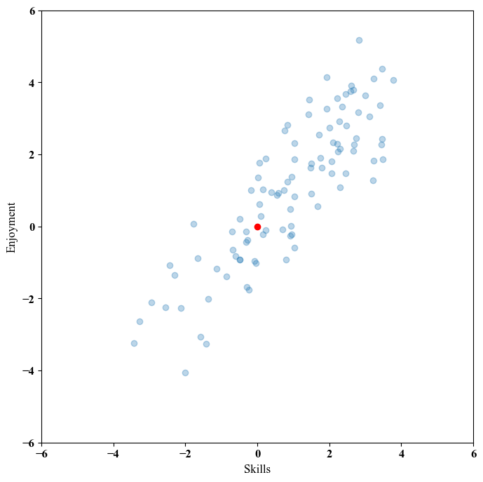

```python
print(f'num of points {X.shape[0]} in dimension {X.shape[1]}')
fig = plt.figure(figsize=(8,8))
plt.scatter(*X.T, alpha=0.3)
plt.scatter(0, 0, c='red')
plt.ylabel('Enjoyment')
plt.xlabel('Skills')
plt.axis('scaled')
plt.xlim(-6, 6)
plt.ylim(-6, 6)
```

```python
# standardize
center = X.mean(axis=0) #X shape is 100x2
std = X.std(axis=0)
Xp = (X-center)/std
```

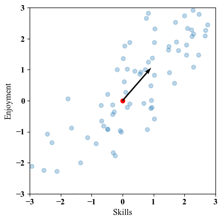

```python
fig = plt.scatter(*X.T, alpha=0.3)
plt.scatter(0, 0, c='red')
plt.quiver(0, 0, *center, angles='xy', scale_units='xy', scale=1)
plt.ylabel('Enjoyment')
plt.xlabel('Skills')
plt.axis('scaled')
plt.xlim(-3, 3)
_=plt.ylim(-3, 3)
#print(center)
```

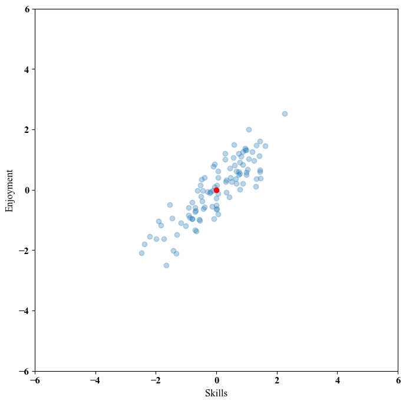

```python
fig = plt.figure(figsize=(8,8))
plt.scatter(*Xp.T, alpha=0.3)
plt.scatter(0, 0, c = 'red')
plt.ylabel('Enjoyment')
plt.xlabel('Skills')
plt.axis('scaled')
plt.xlim(-6, 6)
_=plt.ylim(-6, 6)
```

```python
C = np.cov(X, rowvar=False)
Sigma, U = np.linalg.eig(C)
# If rowvar is True (default), then each row represents a variable,
# with observations in the columns. Otherwise, the relationship
# is transposed: each column represents a variable, while the
# rows contain observations.
```

```python
C.shape
```

```
(2, 2)
```

```python
Sigma.shape, U.shape, Sigma
```

```
((2,), (2, 2), array([0.47772418, 6.90110921]))
```

```python
total_energy = Sigma.sum()
var_exp = Sigma/total_energy
cum_var_exp = np.cumsum(var_exp)
```

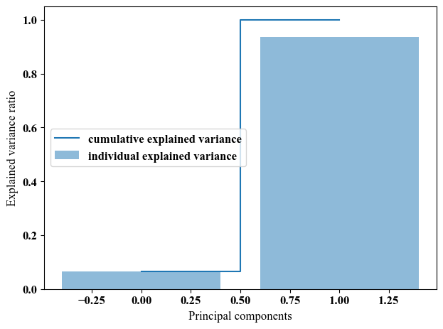

```python
plt.bar(range(len(var_exp)), var_exp, alpha=0.5, align='center',
        label='individual explained variance')
plt.step(range(len(var_exp)), cum_var_exp, where='mid',
         label='cumulative explained variance')
plt.ylabel('Explained variance ratio')
plt.xlabel('Principal components')
plt.legend(loc='best')
plt.tight_layout()
plt.show()
Sigma = np.diag(Sigma)
```

# PCA for projecting/reconstructing data

# No compression, no rotation

Can be seen as reconstructing the data using **U**: $$\underbrace{\mathbf{x}^T}_{2 \times N} = \underbrace{\mathbf{U}}_{2\times 2}\quad\underbrace{\mathbf{U}^T}_{2\times 2}\quad\underbrace{\mathbf{x}^T}_{2\times N}$$

```python
# Full projection
print(U.shape, U.T.shape, Xp.T.shape)
Xd = U @ U.T @ Xp.T  # Our transformation
print(Xd.shape)
```

```
(2, 2) (2, 2) (2, 100)
(2, 100)
```

```python
print('Sigma', Sigma, 'U', U, sep='\n\n')
```

```
Sigma

[[0.47772418 0.        ]
 [0.         6.90110921]]

U

[[-0.76738982 -0.64118083]
 [ 0.64118083 -0.76738982]]
```

## What happens if we use only the first dominant basis (first component)?

```python
Utrunc = U[:,1].reshape(2,-1) # need reshape for matrix mul.
# note [:,1] selects the eigenvector with more energy (highest eigen value)
# if you have more of them you have to sort, with 2 it is easier it is either this or the other
print()
```

```python
# Compressed projection
print('Full projection>', U.shape, U.T.shape, Xp.T.shape)
print('Compressed projection>', Utrunc.shape, Utrunc.T.shape, Xp.T.shape)
Xd = Utrunc.T @ Xp.T  # Our transformation project down = Utrunc.T @ x.T;
print(Xd.shape)
```

```
Full projection> (2, 2) (2, 2) (2, 100)
Compressed projection> (2, 1) (1, 2) (2, 100)
(1, 100)
```

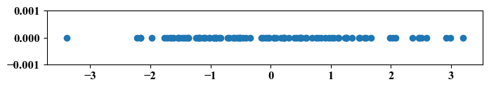

```python
fig = plt.figure(figsize=(8,1))
plt.plot(Xd[0, ...].T, [0]*Xd.shape[1], 'o')
_ = plt.ylim(-0.001, 0.001)
```

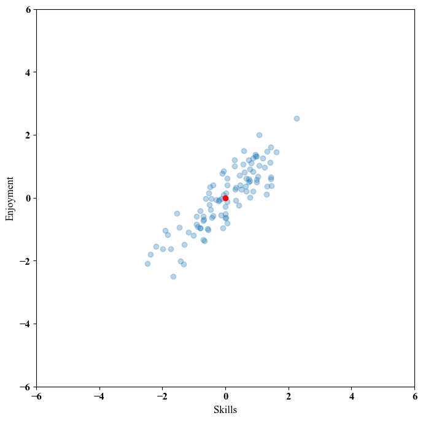

```python
fig = plt.figure(figsize=(8,8))
plt.scatter(*Xp.T, alpha=0.3)
plt.scatter(0, 0, c = 'red')
plt.ylabel('Enjoyment')
plt.xlabel('Skills')
plt.axis('scaled')
plt.xlim(-6, 6)
_=plt.ylim(-6, 6)
```

```python
# Compressed projection and back-projected
print(U.shape, U.T.shape, Xp.T.shape)
Xd = Utrunc @ Utrunc.T @ Xp.T  # Our transformation A = U @ Ut;
print(Xd.shape)
```

```
(2, 2) (2, 2) (2, 100)
(2, 100)
```

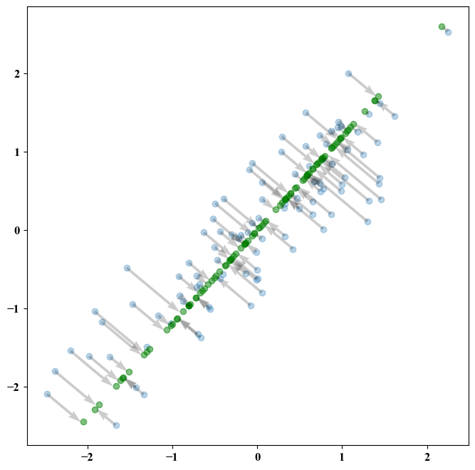

```python
fig, ax = plt.subplots()
fig.set_figheight(8)
fig.set_figwidth(8)
ax.scatter(*Xp.T, alpha=0.3)
ax.scatter(*Xd, color='green', alpha=0.5)
_ = ax.quiver(*Xp.T, *(Xd-Xp.T), alpha=0.2, linestyle='dashed',
          linewidth=.4, color='black')  # start, end-start
```

## We have reduced the dimensionality of the data since we projected on a line

Can be used for compressing and reconstructing the data using **U** up to *k* components: $$\underbrace{\mathbf{x}^T}_{\text{rec}} = \underbrace{\underbrace{\mathbf{U}_{|k}}_{k \mapsto D}\quad\underbrace{\underbrace{\mathbf{U}_{|k}^T}_{D \mapsto k}\quad\underbrace{\mathbf{x}^T}_{\text{orig}}}_{projection}}_{reconstruction}$$

# PCA Full recipe

$$ \mathbf{X}^{\prime} \leftarrow \frac{\mathbf{X} - \mathbf{\mu}}{\boldsymbol{\sigma}} $$$$\underbrace{\mathbf{x}^{T\prime}_p}_{\text{rec}} = \underbrace{\underbrace{\mathbf{U}_{|k}}_{k \mapsto D}\quad\underbrace{\underbrace{\mathbf{U}_{|k}^T}_{D \mapsto k}\quad\underbrace{\mathbf{x}^{T\prime}}_{\text{orig}}}_{projection}}_{reconstruction}$$$$ \mathbf{x}_p\leftarrow\left(\mathbf{x}^{T\prime}_p{\boldsymbol{\sigma}}\right)+\mathbf{\mu}$$

# Example: DNA Analysis

Even linear dimensionality reduction is powerful. Here, in uncovers the geography of European countries from only DNA data

[figure not shown]

# Machine Learning

### 3. PCA in higher dimension, 3DMM, the curse of dimensionality

**Iacopo Masi**

# Recap previous lectures

- Vector and Matrix as a formal way to represent data
- Why LA? (data, covariance matrix, calculus)
- Operations (vector to vector, matrix to vector, inner product)
- Geometric Interpretation of the inner product
- Subspaces/Rank/Inverse
- Projection onto a subspace

# This lecture material is taken from

- ### Note: you can find PCA on Chapter 12 of [Bishop Book]
- [Geometry of the Transformations](https://en.wikipedia.org/wiki/Geometric_transformation)
- [Geometry of Transformations take 2](https://math.hmc.edu/calculus/hmc-mathematics-calculus-online-tutorials/linear-algebra/geometry-of-linear-transformations/)
- [This pdf covers this part](http://cs229.stanford.edu/summer2019/cs229-linalg.pdf)
- [Illustrations and some math parts are taken from d2l.ai, eigendecomposition](https://d2l.ai/chapter_appendix-mathematics-for-deep-learning/eigendecomposition.html)
- [Code for Eigendecomposition](https://hadrienj.github.io/posts/Deep-Learning-Book-Series-2.7-Eigendecomposition/)

# Today's lecture

## Recall PCA (we use projection!) and Eigendecomposition

### Note: you can find PCA on Chapter 12 of [Bishop Book]

## Applications of PCA (3DMM)

# PCA Full recipe

$$ \mathbf{X}^{\prime} \leftarrow \frac{\mathbf{X} - \mathbf{\mu}}{\boldsymbol{\sigma}} $$$$\underbrace{\mathbf{x}^{T\prime}_p}_{\text{rec}} = \underbrace{\underbrace{\mathbf{U}_{|k}}_{k \mapsto D}\quad\underbrace{\underbrace{\mathbf{U}_{|k}^T}_{D \mapsto k}\quad\underbrace{\mathbf{x}^{T\prime}}_{\text{orig}}}_{projection}}_{reconstruction}$$$$ \mathbf{x}_p\leftarrow\left(\mathbf{x}^{T\prime}_p{\boldsymbol{\sigma}}\right)+\mathbf{\mu}$$

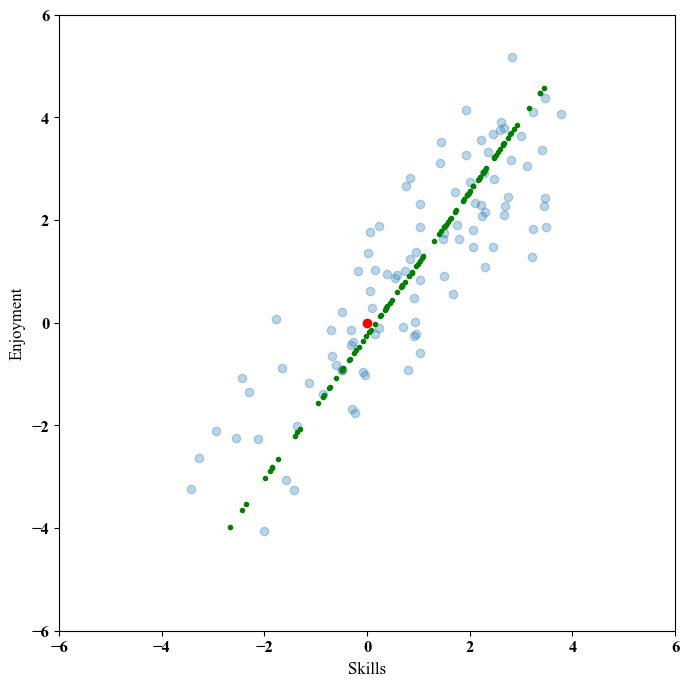

```python
########################################
plt.figure(figsize=(8,8))
plt.scatter(*X.T, alpha=0.3)
plt.scatter(0, 0, c='red')
plt.ylabel('Enjoyment')
plt.xlabel('Skills')
plt.axis('scaled')
plt.xlim(-6, 6)
plt.ylim(-6, 6)
# Taking reconstructed data and shift it back
###############################
Xd_back = (Xd.T*std)+center
#########################
plt.scatter(*Xd_back.T, color='green', marker='.')
```

# Application: PCA to rotate data (make it axis aligned), decorrelate data

## in unsupervised way

- For reading images there are multiple library
- One is Pillow `conda install pillow` or `pip install pillow`

```python
from PIL import Image
import requests
from io import BytesIO

#response = requests.get('https://cdn-icons-png.flaticon.com/512/24/24335.png')
img = Image.open('figs/italy.png')
im = np.array(img)
```

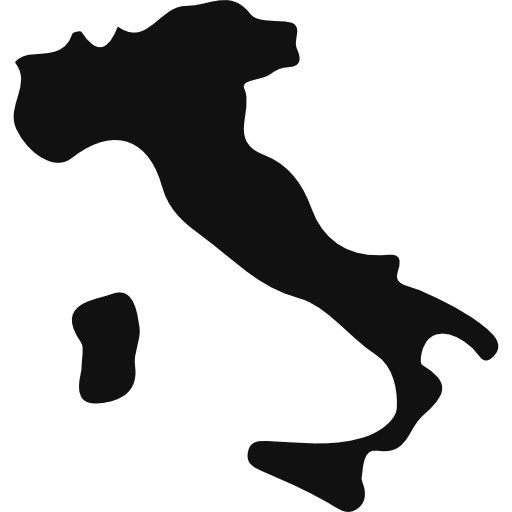

```python
img
```

```python
X, Y = np.where(im != 0)
sampling = 100  # to have less points
X, Y = X[::sampling], Y[::sampling]
```

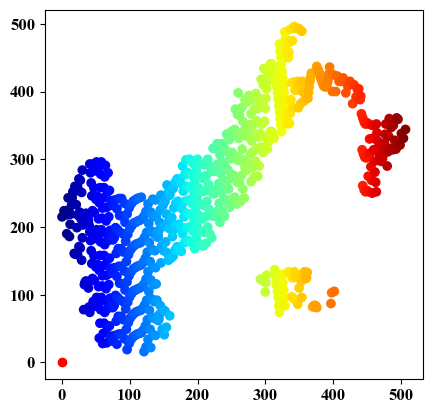

```python
fig = plt.scatter(X, Y, c=X, marker='o', cmap='jet')
plt.scatter(0, 0, c='red')
_ = plt.axis('scaled')
```

# PCA Application - Rotate the data and decorrelate them - No compression

$$ \mathbf{X}^{\prime} \leftarrow \frac{\mathbf{X} - \mathbf{\mu}}{\mathbf{\sigma}} $$$$\underbrace{\mathbf{x}^{T\prime}_p}_{\text{rot}} = {\mathbf{U}^T}\quad\underbrace{\mathbf{x}^{T\prime}}_{\text{orig}}$$$$ \text{Optional:}~~~~ \mathbf{x}_p\leftarrow\left(\mathbf{x}^{T\prime}_p{\mathbf{\sigma}}\right)+\mathbf{\mu}$$

```python
pts = np.stack((X, Y), axis=1)
# Nx2
print(f'num of points {pts.shape[0]} in dimension {pts.shape[1]}' )
```

```
num of points 746 in dimension 2
```

```python
# Standardize the data
# (x-mu)/sigma
center = pts.mean(axis=0)
std = pts.std(axis=0)
pts_z = (pts - center)/std
```

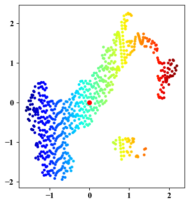

```python
fig = plt.scatter(*pts_z.T, c=X, marker='.', cmap='jet')
plt.scatter(0,0,c='red')
_ = plt.axis('scaled')
```

```python
# np.cov wants features on rows
cov = np.cov(pts_z, rowvar=False)
Sigma, U = np.linalg.eig(cov)
```

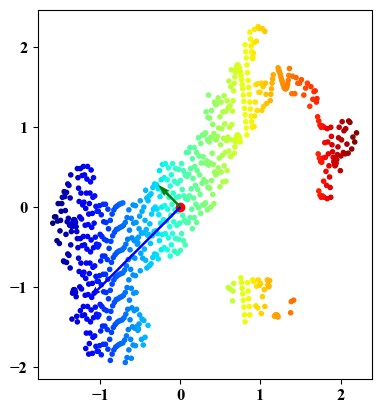

```python
# plot principal components aka eigenvectors
fig = plt.scatter(*pts_z.T, c=X, marker='.', cmap='jet')
plt.scatter(0,0,c='red')
plotVectors(fig.axes, [Sigma[0]*U[:,0], Sigma[1]*U[:,1]], cols=['green','blue'])
_ = plt.axis('scaled')
```

```python
# rotate points
rot = U.T@pts_z.T
np.cov(rot,rowvar=True)
```

```
array([[ 3.95280931e-01, -2.38437160e-18],
       [-2.38437160e-18,  1.60740363e+00]])
```

```
(-3.0, 3.0)
```

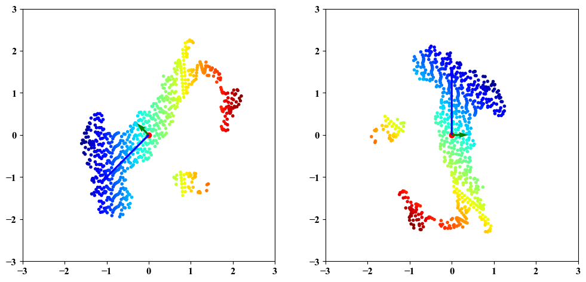

```python
fig, ax = plt.subplots(1,2)
fig.set_figheight(12)
fig.set_figwidth(12)
# First
ax[0].scatter(*pts_z.T, c=X, marker='.', cmap='jet')
ax[0].scatter(0,0,c='red')
plotVectors(ax[0], [Sigma[0]*U[:,0], Sigma[1]*U[:,1]], cols=['green','blue'])
ax[0].set_aspect('equal')
ax[0].set_xlim(-3,3)
ax[0].set_ylim(-3,3)
# second
ax[1].scatter(*rot, c=X, marker='.', cmap='jet')
ax[1].scatter(0,0,c='red')
plotVectors(ax[1], [Sigma[0]*np.array([1,0]), Sigma[1]*np.array([0,1])], cols=['green','blue'])
ax[1].set_aspect('equal')
ax[1].set_xlim(-3,3)
ax[1].set_ylim(-3,3)
```

```python
np.set_printoptions(suppress=True) #suppress scientific notation, please watch out using this
np.cov(rot, rowvar=True) # rowvar is True because matrix is 2xN
# do you know why we get this? and what are the values inside?
```

```
array([[ 0.39528093, -0.        ],
       [-0.        ,  1.60740363]])
```

# Application: Data whitening

What does it mean whitening or sphering?

# Do you remember this?

[figure not shown]

Graphics from Wikipedia

# PCA Application - Whitening - No compression

$$ \mathbf{X}^{\prime} \leftarrow \frac{\mathbf{X} - \mathbf{\mu}}{\mathbf{\sigma}} $$$$\underbrace{\mathbf{x}^{T\prime}_p}_{\text{dec.}} = {\mathbf{\Sigma}^{-1/2}\mathbf{U}^T}\quad\underbrace{\mathbf{x}^{T\prime}}_{\text{orig}}$$

```python
Sigma_inv_sqrt = np.diag(Sigma**-0.5)
# data is rotated and decorrelated (whitening or sphering)
rot_withening = Sigma_inv_sqrt @ U.T @ pts_z.T
```

```
(-3.0, 3.0)
```

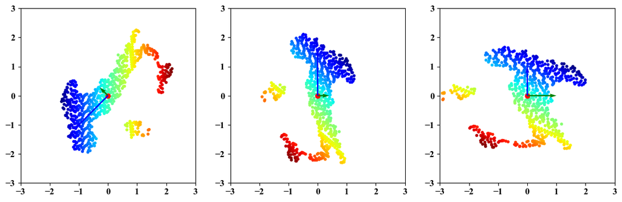

```python
fig, ax = plt.subplots(1,3)
fig.set_figheight(14)
fig.set_figwidth(14)
# First
ax[0].scatter(*pts_z.T, c=X, marker='.', cmap='jet')
ax[0].scatter(0,0,c='red')
plotVectors(ax[0], [Sigma[0]*U[:,0], Sigma[1]*U[:,1]], cols=['green','blue'])
ax[0].set_aspect('equal')
ax[0].set_xlim(-3,3)
ax[0].set_ylim(-3,3)
# second
ax[1].scatter(*rot, c=X, marker='.', cmap='jet')
ax[1].scatter(0,0,c='red')
plotVectors(ax[1], [Sigma[0]*np.array([1,0]), Sigma[1]*np.array([0,1])], cols=['green','blue'])
ax[1].set_aspect('equal')
ax[1].set_xlim(-3,3)
ax[1].set_ylim(-3,3)
# third
ax[2].scatter(*rot_withening, c=X, marker='.', cmap='jet')
ax[2].scatter(0,0,c='red')
plotVectors(ax[2], [np.array([1,0]),
                    np.array([0,1])], cols=['green','blue'])
ax[2].set_aspect('equal')
ax[2].set_xlim(-3,3)
ax[2].set_ylim(-3,3)
```

```
(-3.0, 3.0)
```

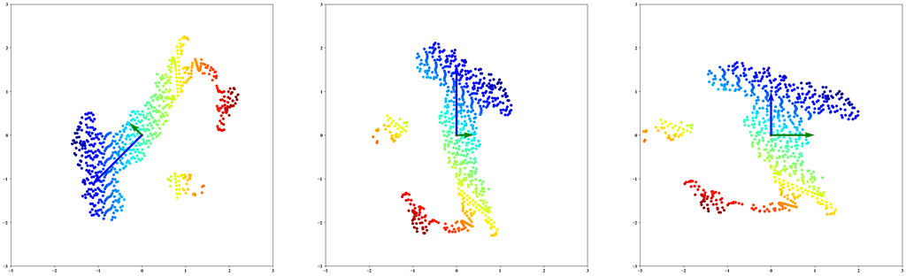

```python
fig, ax = plt.subplots(1,3); sizeim=40;
fig.set_figheight(sizeim)
fig.set_figwidth(sizeim)
# First
ax[0].scatter(*pts_z.T, c=X, marker='o', cmap='jet')
ax[0].scatter(0,0,c='red')
plotVectors(ax[0], [Sigma[0]*U[:,0], Sigma[1]*U[:,1]], cols=['green','blue'])
ax[0].set_aspect('equal')
ax[0].set_xlim(-3,3)
ax[0].set_ylim(-3,3)
# second
ax[1].scatter(*rot, c=X, marker='o', cmap='jet')
ax[1].scatter(0,0,c='red')
plotVectors(ax[1], [Sigma[0]*np.array([1,0]), Sigma[1]*np.array([0,1])], cols=['green','blue'])
ax[1].set_aspect('equal')
ax[1].set_xlim(-3,3)
ax[1].set_ylim(-3,3)
# third
ax[2].scatter(*rot_withening, c=X, marker='o', cmap='jet')
ax[2].scatter(0,0,c='red')
plotVectors(ax[2], [np.array([1,0]),
                    np.array([0,1])], cols=['green','blue'])
ax[2].set_aspect('equal')
ax[2].set_xlim(-3,3)
ax[2].set_ylim(-3,3)
```

# Sanity Check

We take the decorrelated data points and compute the covariance matrix:

$$\mathbf{X}_p\mathbf{X}_p^T$$

if **decorrelated** should get us:

$$ \begin{bmatrix} 1 & 0 \\ 0 & 1 \end{bmatrix} $$

and in more dimensions should give us $\mathbf{I}$ matrix (identity matrix)

```python
np.cov(rot_withening, rowvar=True) # rowvar is True becausse matrix is 2xN
```

```
array([[ 1., -0.],
       [-0.,  1.]])
```

We can also "prove" it that induced decorrelated and "sphered" points:

$$\underbrace{\mathbf{x}^{T\prime}_p}_{\text{dec.}} = {\mathbf{\Sigma}^{-1/2}\mathbf{U}^T}\quad\underbrace{\mathbf{x}^{T\prime}}_{\text{orig}}$$

# Sphering vs Standardization

[figure not shown]

# PCA in Computer Graphics: 3D Morphable Models (3DMM)

- A set of 3D faces point cloud matrix $\mathbf{X}=\{\mathbf{S}_i\}_{i=1}^M$ with $\mathbf{S}_i \in \mathbf{R}^{3N}$ and $M$ are the samples we have.
- $\mathbf{S}_i = [x_1,y_1,z_1,\ldots,x_N,y_N,z_N,]$ point cloud stack in a vector.
- **Assumption**: The point cloud is **vertex-aligned** (usually this implies dense registration, not easy to achieve)
- **Assumption**: $\mathbf{S}\sim\mathcal{N}(\mathbf{\mu},\mathbf{\Sigma})$ faces are modeled as a multivariate Gaussian distribution.

[figure not shown]

Figure Credit [3DMM, Past Present and Future](https://arxiv.org/pdf/1909.01815.pdf)

[figure not shown]

Credits [Blanz and Vetter, 1999](https://gravis.dmi.unibas.ch/publications/Sigg99/morphmod2.pdf)

# 3D Face modeling with PCA

$ \mbf{S}^{\prime} = \mbf{\hat{S}} + \sum_{i}^{M-1} \alpha_i \mbf{U}_i $ where:

- $ \mbf{\hat{S}} $ is the mean shape
- and $\mbf{U}_i$ are the $M-1$ principal components that you can compute by learning PCA on $\mbf{X}=\{\mbf{S}_i\}_{i=1}^M$

## A (new) 3D face is defined once you know $\mbf{\alpha}$

- $ \mbf{\alpha} = [\alpha_1,\ldots,\alpha_k]$ scales each principal component
- Similar to say:
  - OK, this is the average face (fixed for everyone)
  - but I want to edit the average to add `0.25 * male (1st component)` + `-0.12 * caucasian (2nd component)` + `...`

# 3D Face modeling with PCA

$ \mbf{S}^{\prime} = \mbf{\hat{S}} + \sum_{i}^{M-1} \alpha_i \mbf{U}_i $ where:

PCA assumes the data generation process is a **multivariate Gaussian distribution (i.e. a Gaussian/Normal distribution but in 3N-D).**

$ \underbrace{\{\mathbf{S}_i\}_{i=1}^M}_{\text{known}} \sim \underbrace{\mathcal{N}(\mbf{\hat{S}},\mbf{Cov}_S)}_{\text{multivariate Gaussian assumption}} \approx \underbrace{\mathcal{D}}_{\text{unknown}} $

- Given a face $\mbf{\alpha} = [\alpha_1,\ldots,\alpha_k]$ you can compute how much it is likely of "being a face" under $\mathcal{N}(\mbf{\hat{S}},\mbf{Cov}_S)$
- $\mbf{\alpha} = [0.2,\ldots,0.24]$ is **more probable** of being a face (you get something **regular**)
- $\mbf{\alpha} = [0.1,\ldots,-1.24]$ is **less probable** of being a face (you get something **irregular**)

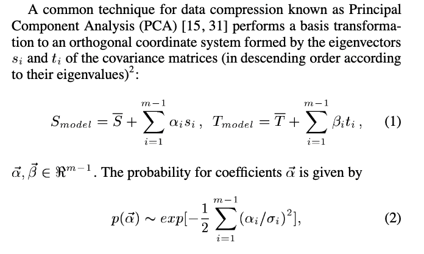

[video not shown]

## Principal Components refers to Variations in Faces

- 1st component: gender or age (most variation)
- 2nd component: face size (moderate variation)
- .....
- last component: nose size etc (least variation)

[figure not shown]

Figure credit [Booth et al. 3DMM in the Wild](https://arxiv.org/pdf/1701.05360.pdf)

[Click here for interactive demo - FLAME - Max Planck](https://flame.is.tue.mpg.de/interactivemodelviewer.html)

# Expressiveness

$\mbf{S}^{\prime} = \mbf{\hat{S}} + \sum_{i}^{M-1} \alpha_i \mbf{U}_i$ where:

- $ \mbf{\hat{S}} $ is the mean shape
- and $\mbf{U}_i$ are the $ M-1 $ principal components that you can compute by learning PCA on $\mbf{X}=\{\mbf{S}_i\}_{i=1}^M$.

# Part-based 3DMM

- The expressiveness of the model can be increased by dividing faces into **independent sub-regions** that are morphed independently, for example into eyes, nose, mouth and a surrounding region.
- Since **all faces are assumed to be in correspondence**, it is sufficient to define these regions on a reference face. This segmentation is equivalent to sub-dividing the vector space of faces into **independent subspaces**.
- A complete 3D face is generated by computing linear combinations for each segment separately and **blending** them at the borders according to an algorithm proposed for images by a blending algorithm

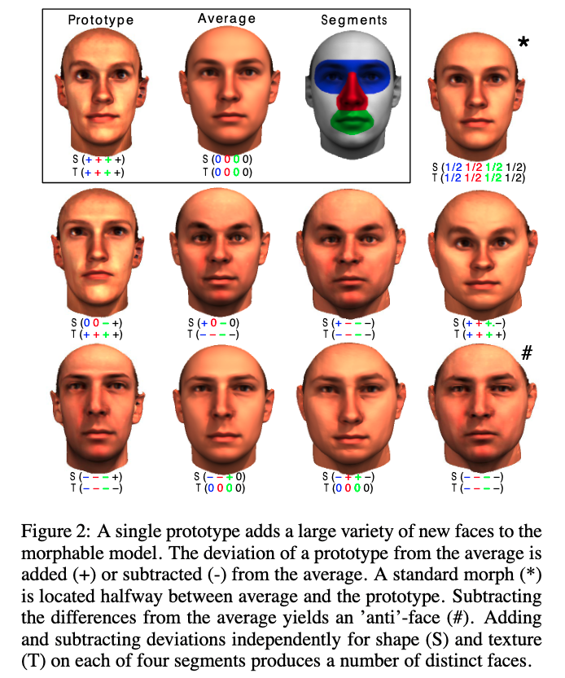

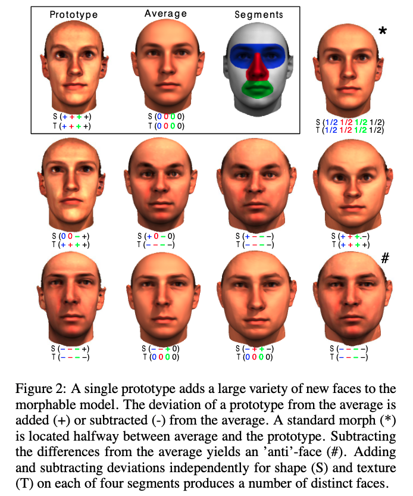

# Two more real world examples

[Morphable Models are everywhere - Snapfeet App](https://snapfeet.io/en/footcompass/)

[Body Morphable Models @ Max Planck Institute for Intelligent Systems](https://bodytalk.is.tue.mpg.de/)

# Up next: PCA in High Dimensional Space

- Demonstration with images
- You can think of an image $\mathbf{I}\in \mathbb{R}^{W\times H}$ as a point/vector in high dimension.
- For an image $128\times 128$ now our $D$ dimension is very high. $D=128^2=(2^7)^2=2^{14}\approx16K$
- Let's double the image $128 \mapsto 256$
- For an image $256\times 256$ now our $D$ dimension is very high. $D=256^2=(2^8)^2=2^{16}\approx65K$
- Doubling a side, increases the dimension four times, for two-dimensional nature of images.

# PCA is in sklearn but implementing it manually is for understanding

```
from sklearn.decomposition import PCA
pca = PCA(n_components=2)
pca.fit(X)
```

## In case you have to use it in industry/thesis, you will rely on `sklearn`

## i.e. "not reinventing the wheel" but academically it is good to do it manually